# Lecture 9 Notes

Quantitative Data Analysis

# Introduction

- Today we will continue our discussion of the assumptions of the linear model
- We began last time by discussing variable selection
- That is a crucial step which begins at the start of a project
- Some of the other assumptions we meet are more technical in nature
- We begin by recapping the five assumptions

# Assumptions

We will consider the following assumptions (taken from Peter Kennedy’s “A guide to econometrics”):

1. The model is correctly specified
2. The residuals have the same variance and are independent of one another
3. There are no exact linear relationships between independent variables
4. The independent variables are fixed and measured without error
5. The expected value of the residual is zero

# The model is well specified

- We have so far assumed a particular functional form of the relationship we are modelling
- For example, for age we assume that being one year older is associated with a fixed change in the estimated wage
- The amount does not depend on the person’s wage or their age, it is a fixed sum of money which is added based on a change in age
- This doesn’t sound particularly sensible for our case
- We need not constrain ourselves in this way

# Visualising non-linearity

- I’m going to switch to another dataset at the moment to demonstrate this point
- R has a built in dataset called *mtcars* which contains some information about different cars
- We are going to look at the relationship between fuel efficiency (mpg) and weight (wt)
- We can load the dataset by typing data(mtcars) into R’s console

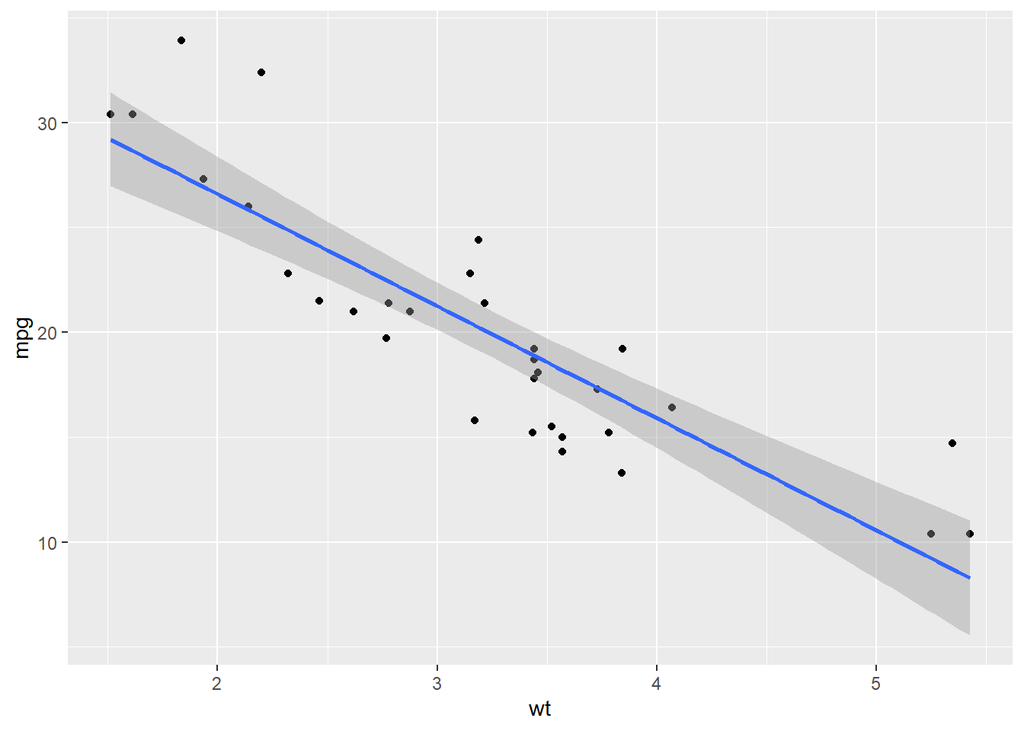

# Thoughts

- The relationship looks relatively linear
- However, the regression underestimates the efficiency of the lightest and heaviest cars
- It does reasonably well in the middle of the range
- One trick to dealing with this is to take a logarithmic transformation of the mpg variable

# Logarithms

- $2^3 = 2 \times 2 \times 2 = 8$
- $\log_28 = 3$
- If $a^x = y$ then $\log_ay = x$
- Here, a is the base of the logarithm
- $\log_28$ asks to what power must we raise 2 to get 8
- Common bases are 10 and $e$ (2.718282…)

# Some rules

- Logarithms are defined only for $x > 0$
- $\log(xy) = \log x + \log y$
- $\log \frac{x}{y} = \log x - \log y$
- $\log x^n = n \log x$

# How does this help?

- We have estimated relationships of the form $y = \beta_0 + \beta_1 x$
- Suppose we think the relationship between $x$ and $y$ should be $y = \beta_0 \cdot x^{\beta_1}$
- We can’t estimate this using OLS because it is nonlinear in its parameters
- Taking logs give us $\log y = \log \beta_0 + \beta_1 \cdot \log x$
- We can estimate this using OLS because it is linear in its parameters
- Let us revisit our plot but this time use a log scale for the `mpg` variable

# Logarithmic transformation

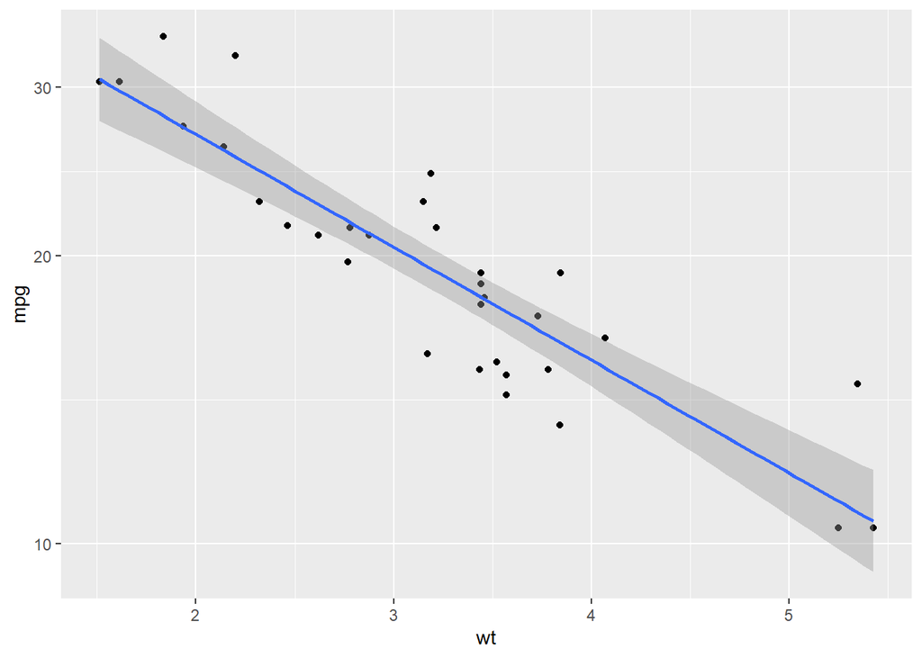

# Logarithmic transformation

- This looks slightly better
- There is less of a tendency of the model to underestimate the upper and lower ends of the distribution
- We could consider also using a logarithmic transformation of the wt variable

# Logarithmic transformation

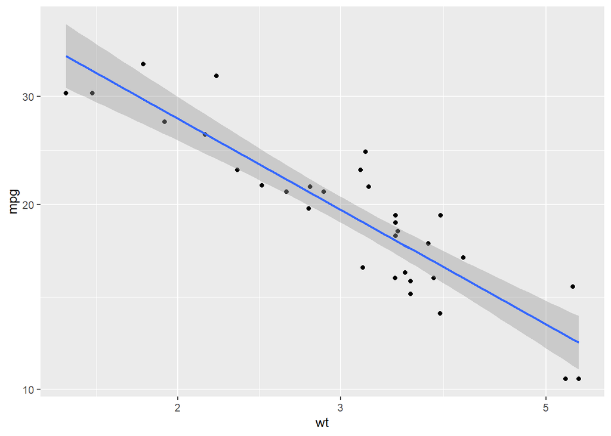